# **Loan Default Prediction**

Raj Goel  
August 2024

## Executive Summary

*Important findings from the analysis done in Milestone 1 - Final proposed model specifications - What are the key next steps?*

**Key Takeaways**

The best model to predict which customers are likely to default is the Random Forest Classifier.

- This model had 87% Precision, 70% Recall, and 78% F1 Score.
- Although Decision Tree catches more defaulters (higher recall), Random Forest avoids more false alarms (higher precision).
- Random Forest has the highest F1 score, which means it provides a better balance because its higher precision will help in catching significant number of defaulters while avoiding unnecessary loan rejections.
- However, if catching every possible defaulter is the top priority, and the cost of false positives is low, then the Tuned Decision Tree could be a viable alternative.

Important features for predicting default:

- A customer's DEBTINC (Debt to Income ratio) is the highest predictor of loan default.
- CLAGE (age of the oldest credit line) is the second most important feature. A longer credit history might indicate a more established and possibly more reliable borrower.
- DELINQ (delinquencies) is also an important predictor.
- VALUE and MORTDUE are also important, indicating that the equity an applicant has in their property is relevant to their likelihood of default.
- REASON and JOB are least critical.

**Final proposed model specifications**

Final proposed model is the Random Forest Classifier, as explained above. We are prioritizing recall and precision over accuracy to minimize financial risk while ensuring that good customers are not unfairly penalized.

Below are the specifications from different models considered:

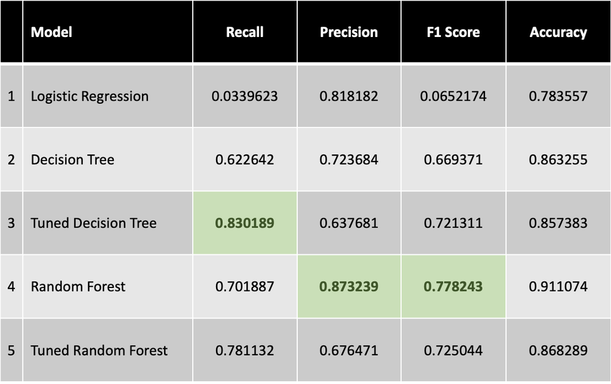

**Takeaways from above table**:

1. Decision Tree catches more defaulters (higher recall).
2. Random Forest avoids more false alarms (higher precision).
3. Recommendation is to go with Random Forest because its higher precision will help in catching significant number of defaulters while avoiding unnecessary loan rejections (higher F1 Score).

**Breakup of specifications by class (BAD=0/1):**

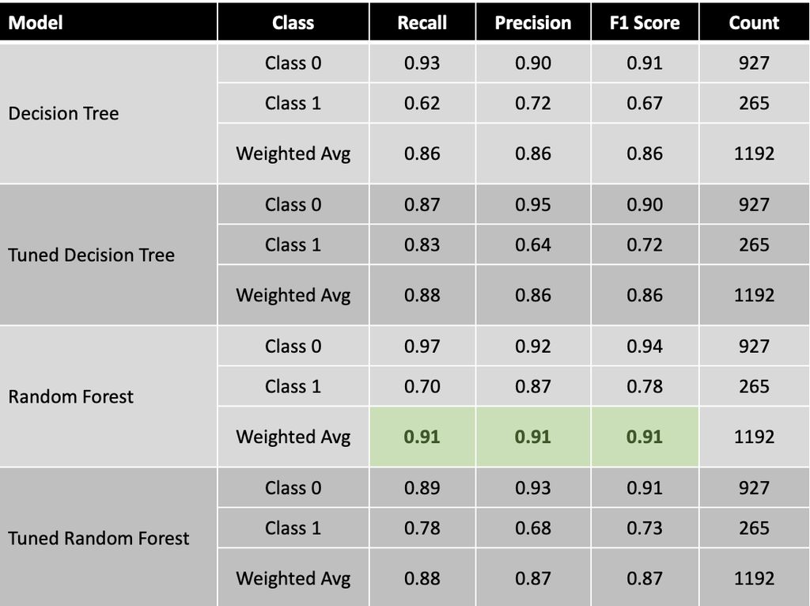

**Takeaways from above table:**

**Next Steps:**

1. Deploy the model for real-time prediction.
2. Establish a maximum Debt to Income Ratio, Delinquencies, and Derogatory reports for loan approvals, based on the above analysis.
3. Monitor the model's performance over time. Retrain as needed to account for changes in the data distribution.

**Problem**

1. For financial institutions, loan defaults represent a significant financial risk. When borrowers fail to repay loans, the lender incurs losses, which can accumulate and potentially threaten the institution's financial stability.
2. By accurately predicting which applicants are likely to default, banks and lending institutions can increase their profits and reduce their losses.

**Solution Summary**

1. Build a predictive classification model that will help the business assess the risk of new loan applicants and make informed decisions on home loan approvals.
2. The model must identify importance of different features, perform well on unseen data sets, and maintain a good balance between false positives and false negatives.

**How will the solution impact the business?**

1. The solution will significantly improve the business's ability to manage credit risk, leading to a reduction in the number of bad loans and improving overall financial stability.
2. With a predictive model in place, decisions on loan approvals will be more data-driven and objective, reducing the likelihood of human error and bias.
3. By reducing defaults, the business can save on costs associated with collections, legal actions, and write-offs, thereby improving the bottom line.

**Recommendations for Implementation**

I recommend the **Random Forest model** because of high recall, high precision, and high F1 score.

1. In a loan default prediction application, you would typically prioritize recall and precision to minimize financial risk while ensuring that good customers are not unfairly penalized. The F1 score would be used to ensure a balance between these two metrics. Accuracy would be less of a focus unless the classes are balanced, and even then, it should be considered alongside precision and recall.
2. A high **recall** is crucial when missing positive cases (false negatives) is very costly. However, high recall can sometimes lead to lower precision, meaning you may capture more positives but at the expense of more false positives.
3. A high **precision** is important when false positives are costly and you want to minimize the number of false positives. However, focusing too much on precision might decrease recall, meaning the model could miss actual positive cases.
4. **F1 score** provides a balance between the two.
5. The Random Forest model has a high recall, high precision, and a better F1 score than other models considered, indicating that it makes fewer mistakes in predicting defaults and offers a better balance between catching defaulters and avoiding false alarms.

The steps to implement the solution are as follows:

1. **Data Preparation**: Clean the dataset by removing duplicates, addressing missing values, and encoding categorical variables into numeric form.
2. **Model Building**: Split the data into 80% training and 20% test data. Train multiple models (Logistic Regression, Decision Tree, Random Forest, etc.) on the training data.
3. **Model Evaluation and Selection**: Evaluate the model performance on the training data set. Test the models on the test date set to ensure they generalize well on new real-world data.
4. **Hyperparameter Tuning**: Fine-tune the selected model's hyperparameters using grid search to optimize performance.
5. **Final Model Validation**: Select the model with the highest recall and precision, to minimize financial risk while ensuring that good customers are not unfairly penalized.
6. **Model Deployment**: Deploy the model for real-time prediction. Monitor the model's performance over time. Retrain as needed to account for changes in the data distribution.

**What are the key actionables for stakeholders?**

1. Integrate the predictive model into existing risk assessment frameworks, enhancing the accuracy and consistency of evaluating borrower risk.
2. Establish thresholds for the different input features discussed here to align with the institution's risk tolerance and financial goals.
3. Track the financial performance of the loan portfolio post-implementation to assess the model's impact on reducing defaults and improving profitability.
4. Set up regular financial reviews to evaluate the cost-benefit analysis of using the predictive model, adjusting strategies as needed.
5. Use the model's insights to personalize loan offers, such as providing better terms to low-risk borrowers and offering tailored solutions to higher-risk individuals.
6. Review the model to ensure that it does not introduce or perpetuate bias against protected groups, and that it complies with fair lending laws.
7. Ensure that the model's decision-making process is transparent and can be explained in detail.

**What is the benefit to the business?**

1. **Reduced loan defaults**: By accurately predicting which borrowers are likely to default, the institution can reduce the number of non-performing loans, leading to fewer write-offs, lower credit losses, and higher profits.
2. **Enhanced decision making**: The model provides data-driven insights, allowing for more precise and consistent loan approval decisions, which can improve the overall quality of the loan portfolio.

**What will be the cost to the business?**

The business will incur cost for infrastructure, model development, deployment, maintenance, compliance, training, etc.

**What will be the risk to the business?**

1. The model may perform well on training data but poorly on new data due to overfitting. This can result in inaccurate predictions when the model is deployed in a real-world environment. Inaccurate predictions can be costly to the business.
2. Over time, the relationships between the features and the loan default rate may change, causing the model's performance to degrade.
3. The model must comply with legal regulations, esp. related to fair lending practices. If the model is found to be discriminatory, the business could face legal penalties.

**What further analysis needs to be done or what other associated problems need to be solved?**

1. The business will need to continuously re-evaluate the costs and financial gains from this deployment to determine ongoing return on investment.
2. The business will need to continuously evaluate other models that may perform better over time due to change in economic conditions, recessions, change in interest rates, etc.
3. Alert systems will need to be put in place.
4. Employees will need to be trained on the new model.

## EVERYTHING BELOW THIS IS FROM MILESTONE 1 SUBMISSION WITH SOME EDITS AND IMPROVEMENTS

## **Problem Definition**

### **The Context:**

- Why is this problem important to solve?

For financial institutions, loan defaults represent a significant financial risk. When borrowers fail to repay loans, the lender incurs losses, which can accumulate and potentially threaten the institution's financial stability. By accurately predicting which applicants are likely to default, banks and lending institutions can increase their profits and reduce their losses.

### **The objective:**

- What is the intended goal?

The goals is to identify high-risk applicants early so the business can reduce the number of defaults, leading to a more profitable outcome for the business Banks can achieve this by building a predictive model that can help the business assess the risk of new loan applicants and make informed decisions on loan approvals.

### **The key questions:**

- What are the key questions that need to be answered?

What are the most important parameters that impact loan default rates? What models should be used to most accurately predict the loan default rates? How will the model's predictions impact the business's financial outcomes, such as reducing losses from defaults or optimizing loan approval rates?

### **The problem formulation**:

- What is it that we are trying to solve using data science?

We are trying to solve the problem of predicting the likelihood of home loan applicants defaulting on their loans. This is a classic predictive modeling problem where the goal is to use historical data to build a model that can forecast future outcomes.

## **Data Description:**

The Home Equity dataset (HMEQ) contains baseline and loan performance information for 5,960 recent home equity loans. The target (BAD) is a binary variable that indicates whether an applicant has ultimately defaulted or has been severely delinquent. This adverse outcome occurred in 1,189 cases (20 percent). 12 input variables were registered for each applicant.

- **BAD:** 1 = Client defaulted on loan, 0 = loan repaid
- **LOAN:** Amount of loan approved.
- **MORTDUE:** Amount due on the existing mortgage.
- **VALUE:** Current value of the property.
- **REASON:** Reason for the loan request. (HomeImp = home improvement, DebtCon= debt consolidation which means taking out a new loan to pay off other liabilities and consumer debts)
- **JOB:** The type of job that loan applicant has such as manager, self, etc.
- **YOJ:** Years at present job.
- **DEROG:** Number of major derogatory reports (which indicates a serious delinquency or late payments).
- **DELINQ:** Number of delinquent credit lines (a line of credit becomes delinquent when a borrower does not make the minimum required payments 30 to 60 days past the day on which the payments were due).
- **CLAGE:** Age of the oldest credit line in months.
- **NINQ:** Number of recent credit inquiries.
- **CLNO:** Number of existing credit lines.
- **DEBTINC:** Debt-to-income ratio (all your monthly debt payments divided by your gross monthly income. This number is one way lenders measure your ability to manage the monthly payments to repay the money you plan to borrow.

## **Important Notes**

- This notebook can be considered a guide to refer to while solving the problem. The evaluation will be as per the Rubric shared for the Milestone. Unlike previous courses, it does not follow the pattern of the graded questions in different sections. This notebook would give you a direction on what steps need to be taken in order to get a viable solution to the problem. Please note that this is just one way of doing this. There can be other 'creative' ways to solve the problem and we urge you to feel free and explore them as an 'optional' exercise.
- In the notebook, there are markdowns cells called - Observations and Insights. It is a good practice to provide observations and extract insights from the outputs.
- The naming convention for different variables can vary. Please consider the code provided in this notebook as a sample code.
- All the outputs in the notebook are just for reference and can be different if you follow a different approach.
- There are sections called **Think About It** in the notebook that will help you get a better understanding of the reasoning behind a particular technique/step. Interested learners can take alternative approaches if they want to explore different techniques.

### **Import the necessary libraries**

```python
import numpy as np
import pandas as pd
import matplotlib.pyplot as plt
import seaborn as sns
sns.set_theme()

from sklearn.model_selection import train_test_split

from sklearn.linear_model import LogisticRegression

from sklearn.preprocessing import OneHotEncoder
from sklearn.compose import ColumnTransformer
from sklearn.pipeline import Pipeline

from sklearn import metrics
from sklearn.metrics import confusion_matrix, classification_report,accuracy_score,precision_score,recall_score,f1_score

from sklearn import tree
from sklearn.tree import DecisionTreeClassifier

from sklearn import ensemble
from sklearn.ensemble import BaggingClassifier
from sklearn.ensemble import RandomForestClassifier

import scipy.stats as stats

from sklearn.model_selection import GridSearchCV


import warnings
warnings.filterwarnings('ignore')
```

### **Read the dataset**

```python
#hm=pd.read_csv("hmeq.csv")

from google.colab import drive

# Read the data from CSV file
drive.mount('/content/drive', force_remount = True)
hm = pd.read_csv("/content/drive/MyDrive/CSV Files/Capstone_Data.csv")
```

```python
# Copying data to another variable to avoid any changes to original data
data=hm.copy()
```

### **Print the first and last 5 rows of the dataset**

```python
data.head(20)
```

|  | BAD | LOAN | MORTDUE | VALUE | REASON | JOB | YOJ | DEROG | DELINQ | CLAGE | NINQ | CLNO | DEBTINC |
| --- | --- | --- | --- | --- | --- | --- | --- | --- | --- | --- | --- | --- | --- |
| 0 | 1 | 1100 | 25860.0 | 39025.0 | HomeImp | Other | 10.5 | 0.0 | 0.0 | 94.366667 | 1.0 | 9.0 | NaN |
| 1 | 1 | 1300 | 70053.0 | 68400.0 | HomeImp | Other | 7.0 | 0.0 | 2.0 | 121.833333 | 0.0 | 14.0 | NaN |
| 2 | 1 | 1500 | 13500.0 | 16700.0 | HomeImp | Other | 4.0 | 0.0 | 0.0 | 149.466667 | 1.0 | 10.0 | NaN |
| 3 | 1 | 1500 | NaN | NaN | NaN | NaN | NaN | NaN | NaN | NaN | NaN | NaN | NaN |
| 4 | 0 | 1700 | 97800.0 | 112000.0 | HomeImp | Office | 3.0 | 0.0 | 0.0 | 93.333333 | 0.0 | 14.0 | NaN |
| 5 | 1 | 1700 | 30548.0 | 40320.0 | HomeImp | Other | 9.0 | 0.0 | 0.0 | 101.466002 | 1.0 | 8.0 | 37.113614 |
| 6 | 1 | 1800 | 48649.0 | 57037.0 | HomeImp | Other | 5.0 | 3.0 | 2.0 | 77.100000 | 1.0 | 17.0 | NaN |
| 7 | 1 | 1800 | 28502.0 | 43034.0 | HomeImp | Other | 11.0 | 0.0 | 0.0 | 88.766030 | 0.0 | 8.0 | 36.884894 |
| 8 | 1 | 2000 | 32700.0 | 46740.0 | HomeImp | Other | 3.0 | 0.0 | 2.0 | 216.933333 | 1.0 | 12.0 | NaN |
| 9 | 1 | 2000 | NaN | 62250.0 | HomeImp | Sales | 16.0 | 0.0 | 0.0 | 115.800000 | 0.0 | 13.0 | NaN |
| 10 | 1 | 2000 | 22608.0 | NaN | NaN | NaN | 18.0 | NaN | NaN | NaN | NaN | NaN | NaN |
| 11 | 1 | 2000 | 20627.0 | 29800.0 | HomeImp | Office | 11.0 | 0.0 | 1.0 | 122.533333 | 1.0 | 9.0 | NaN |
| 12 | 1 | 2000 | 45000.0 | 55000.0 | HomeImp | Other | 3.0 | 0.0 | 0.0 | 86.066667 | 2.0 | 25.0 | NaN |
| 13 | 0 | 2000 | 64536.0 | 87400.0 | NaN | Mgr | 2.5 | 0.0 | 0.0 | 147.133333 | 0.0 | 24.0 | NaN |
| 14 | 1 | 2100 | 71000.0 | 83850.0 | HomeImp | Other | 8.0 | 0.0 | 1.0 | 123.000000 | 0.0 | 16.0 | NaN |
| 15 | 1 | 2200 | 24280.0 | 34687.0 | HomeImp | Other | NaN | 0.0 | 1.0 | 300.866667 | 0.0 | 8.0 | NaN |
| 16 | 1 | 2200 | 90957.0 | 102600.0 | HomeImp | Mgr | 7.0 | 2.0 | 6.0 | 122.900000 | 1.0 | 22.0 | NaN |
| 17 | 1 | 2200 | 23030.0 | NaN | NaN | NaN | 19.0 | NaN | NaN | NaN | NaN | NaN | 3.711312 |
| 18 | 1 | 2300 | 28192.0 | 40150.0 | HomeImp | Other | 4.5 | 0.0 | 0.0 | 54.600000 | 1.0 | 16.0 | NaN |
| 19 | 0 | 2300 | 102370.0 | 120953.0 | HomeImp | Office | 2.0 | 0.0 | 0.0 | 90.992533 | 0.0 | 13.0 | 31.588503 |

```python
# Display last 5 rows
data.tail(5)
```

|  | BAD | LOAN | MORTDUE | VALUE | REASON | JOB | YOJ | DEROG | DELINQ | CLAGE | NINQ | CLNO | DEBTINC |
| --- | --- | --- | --- | --- | --- | --- | --- | --- | --- | --- | --- | --- | --- |
| 5955 | 0 | 88900 | 57264.0 | 90185.0 | DebtCon | Other | 16.0 | 0.0 | 0.0 | 221.808718 | 0.0 | 16.0 | 36.112347 |
| 5956 | 0 | 89000 | 54576.0 | 92937.0 | DebtCon | Other | 16.0 | 0.0 | 0.0 | 208.692070 | 0.0 | 15.0 | 35.859971 |
| 5957 | 0 | 89200 | 54045.0 | 92924.0 | DebtCon | Other | 15.0 | 0.0 | 0.0 | 212.279697 | 0.0 | 15.0 | 35.556590 |
| 5958 | 0 | 89800 | 50370.0 | 91861.0 | DebtCon | Other | 14.0 | 0.0 | 0.0 | 213.892709 | 0.0 | 16.0 | 34.340882 |
| 5959 | 0 | 89900 | 48811.0 | 88934.0 | DebtCon | Other | 15.0 | 0.0 | 0.0 | 219.601002 | 0.0 | 16.0 | 34.571519 |

### **Understand the shape of the dataset**

```python
# How many rows and columns in the data?
print("The data has", data.shape[0], "rows and", data.shape[1], "columns.")
```

```
The data has 5960 rows and 13 columns.
```

**Insights: The data has 5960 rows and 13 columns.**

### **Check the data types of the columns**

```python
# What are the data types for the different columns?
data.info()
```

```
<class 'pandas.core.frame.DataFrame'>
RangeIndex: 5960 entries, 0 to 5959
Data columns (total 13 columns):
 #   Column   Non-Null Count  Dtype
---  ------   --------------  -----
 0   BAD      5960 non-null   int64
 1   LOAN     5960 non-null   int64
 2   MORTDUE  5442 non-null   float64
 3   VALUE    5848 non-null   float64
 4   REASON   5708 non-null   object
 5   JOB      5681 non-null   object
 6   YOJ      5445 non-null   float64
 7   DEROG    5252 non-null   float64
 8   DELINQ   5380 non-null   float64
 9   CLAGE    5652 non-null   float64
 10  NINQ     5450 non-null   float64
 11  CLNO     5738 non-null   float64
 12  DEBTINC  4693 non-null   float64
dtypes: float64(9), int64(2), object(2)
memory usage: 605.4+ KB
```

**Insights: Except REASON and JOB, all other fields are numeric.**

### **Check for missing values**

```python
# Check for duplicate values in the data
data.duplicated()
```

|  | 0 |
| --- | --- |
| 0 | False |
| 1 | False |
| 2 | False |
| 3 | False |
| 4 | False |
| ... | ... |
| 5955 | False |
| 5956 | False |
| 5957 | False |
| 5958 | False |
| 5959 | False |

5960 rows × 1 columns

**dtype:** bool

```python
# Print the statistical summary of the data
data.describe()
```

|  | BAD | LOAN | MORTDUE | VALUE | YOJ | DEROG | DELINQ | CLAGE | NINQ | CLNO | DEBTINC |
| --- | --- | --- | --- | --- | --- | --- | --- | --- | --- | --- | --- |
| count | 5960.000000 | 5960.000000 | 5442.000000 | 5848.000000 | 5445.000000 | 5252.000000 | 5380.000000 | 5652.000000 | 5450.000000 | 5738.000000 | 4693.000000 |
| mean | 0.199497 | 18607.969799 | 73760.817200 | 101776.048741 | 8.922268 | 0.254570 | 0.449442 | 179.766275 | 1.186055 | 21.296096 | 33.779915 |
| std | 0.399656 | 11207.480417 | 44457.609458 | 57385.775334 | 7.573982 | 0.846047 | 1.127266 | 85.810092 | 1.728675 | 10.138933 | 8.601746 |
| min | 0.000000 | 1100.000000 | 2063.000000 | 8000.000000 | 0.000000 | 0.000000 | 0.000000 | 0.000000 | 0.000000 | 0.000000 | 0.524499 |
| 25% | 0.000000 | 11100.000000 | 46276.000000 | 66075.500000 | 3.000000 | 0.000000 | 0.000000 | 115.116702 | 0.000000 | 15.000000 | 29.140031 |
| 50% | 0.000000 | 16300.000000 | 65019.000000 | 89235.500000 | 7.000000 | 0.000000 | 0.000000 | 173.466667 | 1.000000 | 20.000000 | 34.818262 |
| 75% | 0.000000 | 23300.000000 | 91488.000000 | 119824.250000 | 13.000000 | 0.000000 | 0.000000 | 231.562278 | 2.000000 | 26.000000 | 39.003141 |
| max | 1.000000 | 89900.000000 | 399550.000000 | 855909.000000 | 41.000000 | 10.000000 | 15.000000 | 1168.233561 | 17.000000 | 71.000000 | 203.312149 |

```python
# Print sorted list of count of missing values
data.isnull().sum().sort_values(ascending=False)
```

|  | 0 |
| --- | --- |
| DEBTINC | 1267 |
| DEROG | 708 |
| DELINQ | 580 |
| MORTDUE | 518 |
| YOJ | 515 |
| NINQ | 510 |
| CLAGE | 308 |
| JOB | 279 |
| REASON | 252 |
| CLNO | 222 |
| VALUE | 112 |
| BAD | 0 |
| LOAN | 0 |

**dtype:** int64

```python
# Check the percentage of missing values in each column
percent_missing = data.isnull().sum()*100/len(data)
missing_value_df = pd.DataFrame({'column name': data.columns,
                                 'percent_missing': percent_missing})

# Sort the percent missing values by column
missing_value_df.sort_values('percent_missing', inplace=True, ascending=False)
print(missing_value_df)
```

```
        column name  percent_missing
DEBTINC     DEBTINC        21.258389
DEROG         DEROG        11.879195
DELINQ       DELINQ         9.731544
MORTDUE     MORTDUE         8.691275
YOJ             YOJ         8.640940
NINQ           NINQ         8.557047
CLAGE         CLAGE         5.167785
JOB             JOB         4.681208
REASON       REASON         4.228188
CLNO           CLNO         3.724832
VALUE         VALUE         1.879195
BAD             BAD         0.000000
LOAN           LOAN         0.000000
```

**Insights: Debt to Income ratio is missing in 21% of the records**

### **Think about it:**

- We found the total number of missing values and the percentage of missing values, which is better to consider?

It's better to consider the percentage of missing values rather than the absolute number of missing values, for the following reasons:

1. The total number of missing values can be misleading if you don't take into account the size of the dataset.
2. The percentage of missing values helps you decide whether to fill, drop, or handle the missing data differently.
3. When comparing missing values across different features, the percentage allows for a more meaningful comparison, especially when the features have different scales or number of entries.
- What can be the limit for % missing values in a column in order to avoid it and what are the challenges associated with filling them and avoiding them?

If a data set has > 10% missing values, better to not fill it because filling may impact the performance of the model.

**We can convert the object type columns to categories**

`converting "objects" to "category" reduces the data space required to store the dataframe`

### **Convert the data types**

```python
cols = data.select_dtypes(['object']).columns.tolist()

#adding target variable to this list as this is a classification problem and the target variable is categorical

cols.append('BAD')
```

```python
cols
```

```
['REASON', 'JOB', 'BAD']
```

```python
# Change the data type of object type column to category
for i in cols:
    data[i] = data[i].astype('category')
```

```python
# Check the info again and the datatype of different variable
data.info()
```

```
<class 'pandas.core.frame.DataFrame'>
RangeIndex: 5960 entries, 0 to 5959
Data columns (total 13 columns):
 #   Column   Non-Null Count  Dtype
---  ------   --------------  -----
 0   BAD      5960 non-null   category
 1   LOAN     5960 non-null   int64
 2   MORTDUE  5442 non-null   float64
 3   VALUE    5848 non-null   float64
 4   REASON   5708 non-null   category
 5   JOB      5681 non-null   category
 6   YOJ      5445 non-null   float64
 7   DEROG    5252 non-null   float64
 8   DELINQ   5380 non-null   float64
 9   CLAGE    5652 non-null   float64
 10  NINQ     5450 non-null   float64
 11  CLNO     5738 non-null   float64
 12  DEBTINC  4693 non-null   float64
dtypes: category(3), float64(9), int64(1)
memory usage: 483.7 KB
```

### **Analyze Summary Statistics of the dataset**

```python
# Analyze the summary statistics for numerical variables
data.describe().T
```

|  | count | mean | std | min | 25% | 50% | 75% | max |
| --- | --- | --- | --- | --- | --- | --- | --- | --- |
| LOAN | 5960.0 | 18607.969799 | 11207.480417 | 1100.000000 | 11100.000000 | 16300.000000 | 23300.000000 | 89900.000000 |
| MORTDUE | 5442.0 | 73760.817200 | 44457.609458 | 2063.000000 | 46276.000000 | 65019.000000 | 91488.000000 | 399550.000000 |
| VALUE | 5848.0 | 101776.048741 | 57385.775334 | 8000.000000 | 66075.500000 | 89235.500000 | 119824.250000 | 855909.000000 |
| YOJ | 5445.0 | 8.922268 | 7.573982 | 0.000000 | 3.000000 | 7.000000 | 13.000000 | 41.000000 |
| DEROG | 5252.0 | 0.254570 | 0.846047 | 0.000000 | 0.000000 | 0.000000 | 0.000000 | 10.000000 |
| DELINQ | 5380.0 | 0.449442 | 1.127266 | 0.000000 | 0.000000 | 0.000000 | 0.000000 | 15.000000 |
| CLAGE | 5652.0 | 179.766275 | 85.810092 | 0.000000 | 115.116702 | 173.466667 | 231.562278 | 1168.233561 |
| NINQ | 5450.0 | 1.186055 | 1.728675 | 0.000000 | 0.000000 | 1.000000 | 2.000000 | 17.000000 |
| CLNO | 5738.0 | 21.296096 | 10.138933 | 0.000000 | 15.000000 | 20.000000 | 26.000000 | 71.000000 |
| DEBTINC | 4693.0 | 33.779915 | 8.601746 | 0.524499 | 29.140031 | 34.818262 | 39.003141 | 203.312149 |

**Insights: Median loan amount is \$16300. Median mortgage value is \$65019. Median home value is \$89235.**

```python
# Check summary for categorical data
data.describe(include=['category']).T
```

|  | count | unique | top | freq |
| --- | --- | --- | --- | --- |
| BAD | 5960 | 2 | 0 | 4771 |
| REASON | 5708 | 2 | DebtCon | 3928 |
| JOB | 5681 | 6 | Other | 2388 |

**Insights: Most loan applications are for debt consolidation.**

**Let's look at the unique values in all the categorical variables**

```python
# Check the count of unique values in each categorical column

cols_cat= data.select_dtypes(['category'])

for i in cols_cat.columns:
    print('Unique values in',i, ':')
    print(data[i].unique())
    print('*'*40)
    print()
```

```
Unique values in BAD :
[1, 0]
Categories (2, int64): [0, 1]

Unique values in REASON :
['HomeImp', NaN, 'DebtCon']
Categories (2, object): ['DebtCon', 'HomeImp']

Unique values in JOB :
['Other', NaN, 'Office', 'Sales', 'Mgr', 'ProfExe', 'Self']
Categories (6, object): ['Mgr', 'Office', 'Other', 'ProfExe', 'Sales', 'Self']
```

**Insights:**

The absolute count of unique values in each categorical column is a useful metric, but it might not be sufficient on its own to assess the quality or importance of a categorical feature.

The absolute count of unique values tells you how many distinct categories are present, but it doesn’t inform you about the distribution of these categories.

Just knowing the number of unique categories doesn’t tell you how important the feature is for predicting the target variable.

A frequency distribution will be more useful.

### **Think about it**

- The results above gave the absolute count of unique values in each categorical column. Are absolute values a good measure?
- If not, what else can be used? Try implementing that.

```python
# Print frequency distribution of REASON
frequency_distribution = data['REASON'].value_counts(normalize=True)
print(frequency_distribution)

print()

# Print frequency distribution of JOB
frequency_distribution = data['JOB'].value_counts(normalize=True)
print(frequency_distribution)
```

```
REASON
DebtCon    0.688157
HomeImp    0.311843
Name: proportion, dtype: float64

JOB
Other      0.420349
ProfExe    0.224608
Office     0.166872
Mgr        0.135011
Self       0.033973
Sales      0.019187
Name: proportion, dtype: float64
```

## **Exploratory Data Analysis (EDA) and Visualization**

## **Univariate Analysis**

Univariate analysis is used to explore each variable in a data set, separately. It looks at the range of values, as well as the central tendency of the values. It can be done for both numerical and categorical variables

### **1. Univariate Analysis - Numerical Data**

Histograms and box plots help to visualize and describe numerical data. We use box plot and histogram to analyze the numerical columns.

```python
# While doing uni-variate analysis of numerical variables we want to study their central tendency and dispersion.
# Let us write a function that will help us create boxplot and histogram for any input numerical variable.
# This function takes the numerical column as the input and return the boxplots and histograms for the variable.
# Let us see if this help us write faster and cleaner code.
def histogram_boxplot(feature, figsize=(15,10), bins = None):
    """ Boxplot and histogram combined
    feature: 1-d feature array
    figsize: size of fig (default (9,8))
    bins: number of bins (default None / auto)
    """
    f2, (ax_box2, ax_hist2) = plt.subplots(nrows = 2, # Number of rows of the subplot grid= 2
                                           sharex = True, # x-axis will be shared among all subplots
                                           gridspec_kw = {"height_ratios": (.25, .75)},
                                           figsize = figsize
                                           ) # creating the 2 subplots
    sns.boxplot(feature, ax=ax_box2, showmeans=True, color='violet') # boxplot will be created and a star will indicate the mean value of the column
    sns.histplot(feature, kde=F, ax=ax_hist2, bins=bins,palette="winter") if bins else sns.histplot(feature, kde=False, ax=ax_hist2) # For histogram
    ax_hist2.axvline(np.mean(feature), color='green', linestyle='--') # Add mean to the histogram
    ax_hist2.axvline(np.median(feature), color='black', linestyle='-') # Add median to the histogram
```

#### Using the above function, let's first analyze the Histogram and Boxplot for LOAN

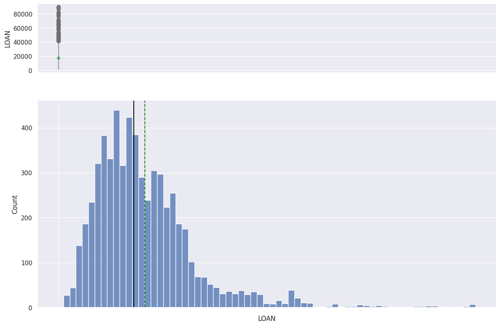

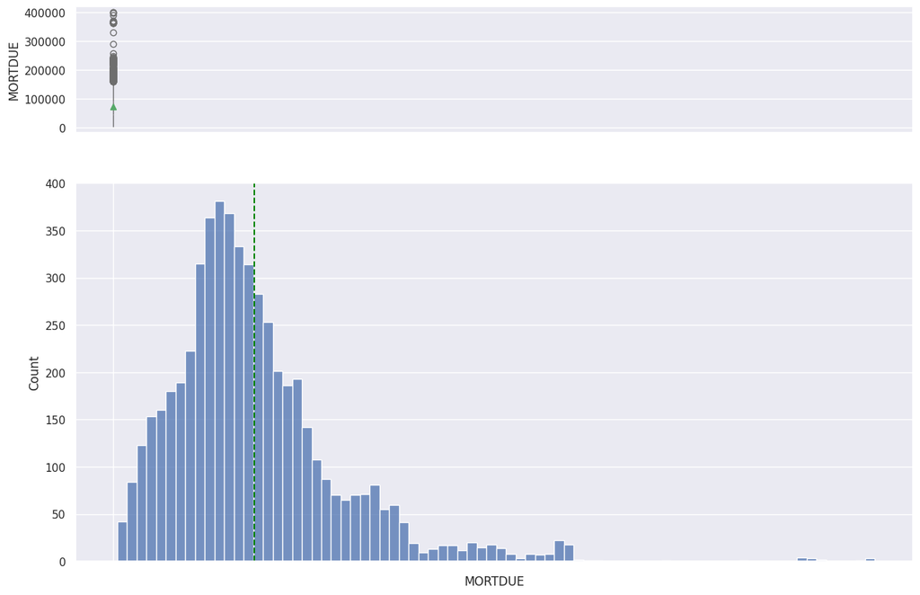

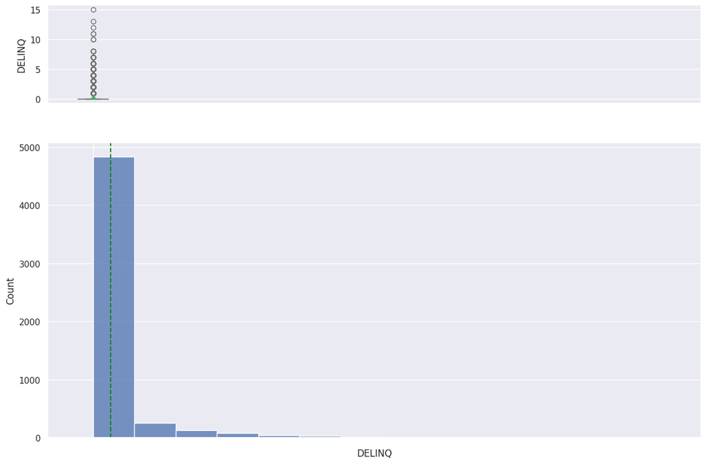

```python
# Build the histogram boxplot for Loan
histogram_boxplot(data['LOAN'])
print()

# Build the histogram boxplot for Mortgage Due
histogram_boxplot(data['MORTDUE'])

print()

# Build the histogram boxplot for Delinquencies
histogram_boxplot(data['DELINQ'])
```

### **2. Univariate Analysis - Categorical Data**

```python
# Function to create barplots that indicate percentage for each category.

def perc_on_bar(plot, feature):
    '''
    plot
    feature: categorical feature
    the function won't work if a column is passed in hue parameter
    '''

    total = len(feature) # length of the column
    for p in ax.patches:
        percentage = '{:.1f}%'.format(100 * p.get_height()/total) # percentage of each class of the category
        x = p.get_x() + p.get_width() / 2 - 0.05 # width of the plot
        y = p.get_y() + p.get_height()           # height of the plot
        ax.annotate(percentage, (x, y), size = 12) # annotate the percentage

    plt.show() # show the plot
```

#### Analyze Barplot for DELINQ

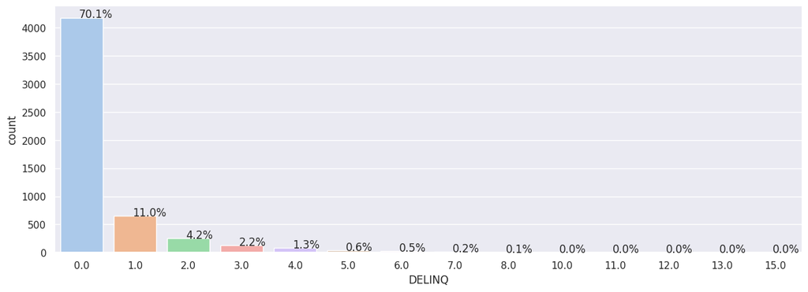

```python
#Build barplot for DELINQ
plt.figure(figsize=(15,5))
ax = sns.countplot(x=data["DELINQ"],palette='pastel')
perc_on_bar(ax,data["DELINQ"])
```

## **Bivariate Analysis**

### **Bivariate Analysis: Continuous and Categorical Variables**

#### Analyze BAD vs Loan

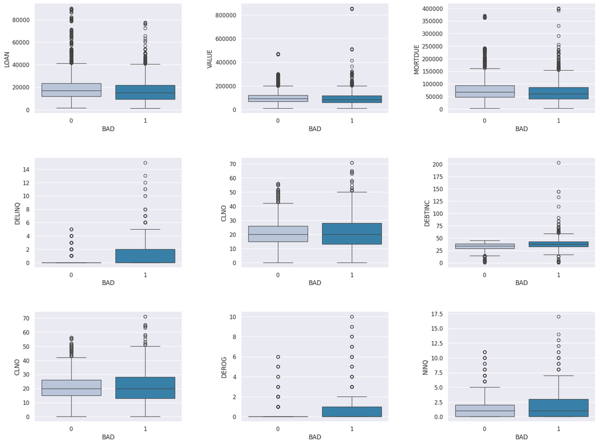

```python
fig = plt.figure(figsize = (20,15))
fig.subplots_adjust(hspace=0.4, wspace=0.4)

ax = fig.add_subplot(3, 3, 1)
sns.boxplot(x=data["BAD"],y=data['LOAN'],palette="PuBu")

ax = fig.add_subplot(3, 3, 2)
sns.boxplot(x=data["BAD"],y=data['VALUE'],palette="PuBu")

ax = fig.add_subplot(3, 3, 3)
sns.boxplot(x=data["BAD"],y=data['MORTDUE'],palette="PuBu")

ax = fig.add_subplot(3, 3, 4)
sns.boxplot(x=data["BAD"],y=data['DELINQ'],palette="PuBu")

ax = fig.add_subplot(3, 3, 5)
sns.boxplot(x=data["BAD"],y=data['CLNO'],palette="PuBu")

ax = fig.add_subplot(3, 3, 6)
sns.boxplot(x=data["BAD"],y=data['DEBTINC'],palette="PuBu")

ax = fig.add_subplot(3, 3, 7)
sns.boxplot(x=data["BAD"],y=data['CLNO'],palette="PuBu")

ax = fig.add_subplot(3, 3, 8)
sns.boxplot(x=data["BAD"],y=data['DEROG'],palette="PuBu")

ax = fig.add_subplot(3, 3, 9)
sns.boxplot(x=data["BAD"],y=data['NINQ'],palette="PuBu")
```

**Insights: DEROG and DELINQ have a definite impact on BAD. Followed by DEBTINC and NINQ.**

```python
### Function to plot stacked bar charts for categorical columns

def stacked_barplot(data, predictor, target):
    """
    Print the category counts and plot a stacked bar chart

    data: dataframe
    predictor: independent variable
    target: target variable
    """
    count = data[predictor].nunique()
    sorter = data[target].value_counts().index[-1]
    tab1 = pd.crosstab(data[predictor], data[target], margins=True).sort_values(
        by=sorter, ascending=False
    )
#    print(tab1)
#    print("-" * 120)
    tab = pd.crosstab(data[predictor], data[target], normalize="index").sort_values(
        by=sorter, ascending=False
    )
    tab.plot(kind="bar", stacked=True, figsize=(count + 5, 5))
    plt.legend(
        loc="lower left", frameon=False,
    )
    plt.legend(loc="upper left", bbox_to_anchor=(1, 1))
    plt.show()

def stacked_plot(x):
    sns.set(palette='nipy_spectral')
    tab1 = pd.crosstab(x,data['BAD'],margins=True)
    print(tab1)
    print('-'*120)
    tab = pd.crosstab(x,data['BAD'],normalize='index')
    tab.plot(kind='bar',stacked=True,figsize=(10,5))
    plt.legend(loc='lower left', frameon=False)
    plt.legend(loc="upper left", bbox_to_anchor=(1,1))
    plt.show()
```

### **Bivariate Analysis: Two Continuous Variables**

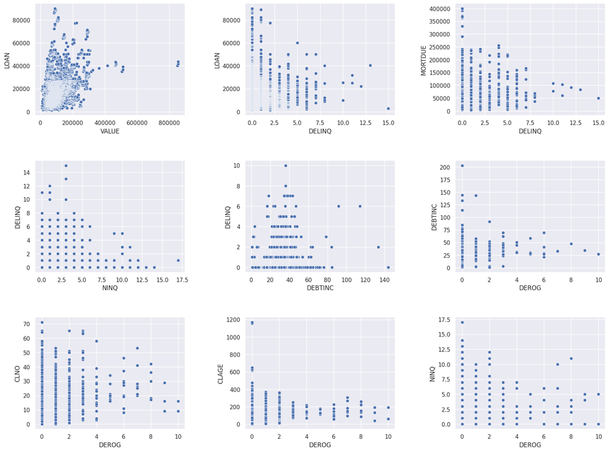

```python
fig = plt.figure(figsize = (20,15))
fig.subplots_adjust(hspace=0.4, wspace=0.4)

ax = fig.add_subplot(3, 3, 1)
sns.scatterplot(x=data["VALUE"],y=data['LOAN'],palette="PuBu")

ax = fig.add_subplot(3, 3, 2)
sns.scatterplot(x=data["DELINQ"],y=data['LOAN'],palette="PuBu")

ax = fig.add_subplot(3, 3, 3)
sns.scatterplot(x=data["DELINQ"],y=data['MORTDUE'],palette="PuBu")

ax = fig.add_subplot(3, 3, 4)
sns.scatterplot(x=data["NINQ"],y=data['DELINQ'],palette="PuBu")

ax = fig.add_subplot(3, 3, 5)
sns.scatterplot(x=data["DEBTINC"],y=data['DELINQ'],palette="PuBu")

ax = fig.add_subplot(3, 3, 6)
sns.scatterplot(x=data["DEROG"],y=data['DEBTINC'],palette="PuBu")

ax = fig.add_subplot(3, 3, 7)
sns.scatterplot(x=data["DEROG"],y=data['CLNO'],palette="PuBu")

ax = fig.add_subplot(3, 3, 8)
sns.scatterplot(x=data["DEROG"],y=data['CLAGE'],palette="PuBu")

ax = fig.add_subplot(3, 3, 9)
sns.scatterplot(x=data["DEROG"],y=data['NINQ'],palette="PuBu")
```

### **Bivariate Analysis: BAD vs Categorical Variables**

**The stacked bar chart (aka stacked bar graph)** extends the standard bar chart from looking at numeric values across one categorical variable to two.

#### Plot stacked bar plot for for BAD and REASON

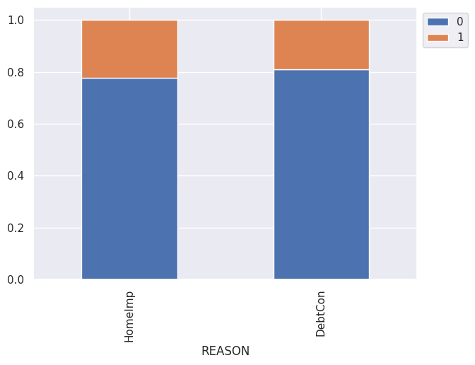

```python
# Plot stacked bar plot for BAD and REASON
stacked_barplot(data, "REASON", "BAD")
```

**Insights: Loan Reason has an insignificant impact on default.**

### **Multivariate Analysis**

#### Analyze Correlation Heatmap for Numerical Variables

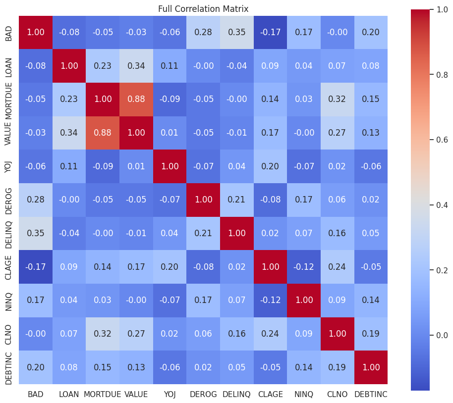

```python
# Convert 'BAD' to numeric
data['BAD'] = pd.to_numeric(data['BAD'], errors='coerce')

# Select only the numeric columns from the data, ensuring 'BAD' is included
numeric_data = data.select_dtypes(include=['float64', 'int64'])

# Calculate the full correlation matrix
full_corr_matrix = numeric_data.corr()

# Plotting the full correlation matrix
plt.figure(figsize=(12, 10))
sns.heatmap(full_corr_matrix, annot=True, fmt='.2f', cmap='coolwarm', cbar=True, square=True)
plt.title("Full Correlation Matrix")
plt.show()
```

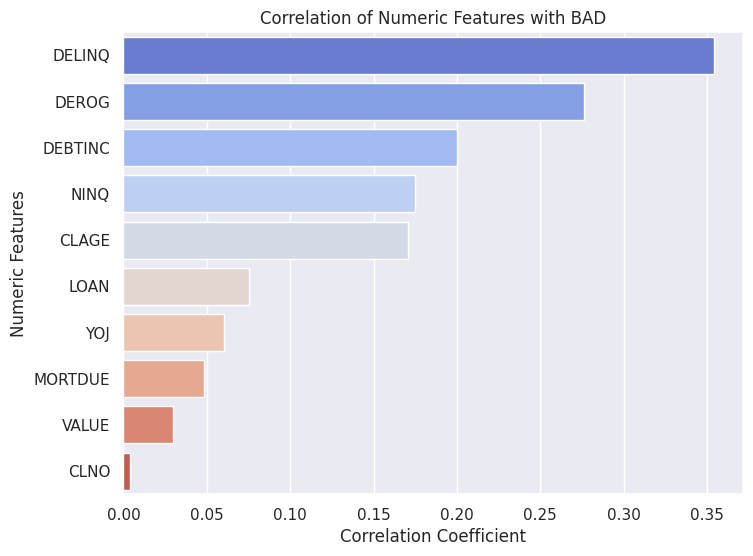

```python
# Calculate the correlation of the numeric features to BAD

# Convert 'BAD' to numeric
data['BAD'] = pd.to_numeric(data['BAD'], errors='coerce')

# Select only the numeric columns from the DataFrame, ensuring 'BAD' is included
numeric_data = data.select_dtypes(include=['float64', 'int64'])

# Calculate the correlation matrix for 'BAD' vs numeric parameters
corr_matrix = numeric_data.corr()

# Check if 'BAD' exists after conversion and selection
if 'BAD' in corr_matrix.columns:
    # Extract the correlation of all numeric features with 'BAD'
    corr_bad = corr_matrix["BAD"].drop("BAD")  # Drop the BAD column correlation with itself

    # Sort correlations by absolute value
    corr_bad_sorted = corr_bad.abs().sort_values(ascending=False)

    # Plotting the correlation matrix
    plt.figure(figsize=(8, 6))
    sns.barplot(x=corr_bad_sorted.values, y=corr_bad_sorted.index, palette="coolwarm")
    plt.title("Correlation of Numeric Features with BAD")
    plt.xlabel("Correlation Coefficient")
    plt.ylabel("Numeric Features")
    plt.show()
else:
    print("The 'BAD' column could not be found in the numeric data.")
```

```python
# Build pairplot for the data with hue = 'BAD'
#numerical_data = data.select_dtypes(include=np.number)
numerical_data = data.drop(['REASON','JOB'],axis=1)

sns.pairplot(numerical_data, hue='BAD')
plt.show()
```

```
Output hidden; open in https://colab.research.google.com to view.
```

### **Think about it**

- Are there missing values and outliers in the dataset? If yes, how can you treat them?
- Can you think of different ways in which this can be done and when to treat these outliers or not?
- Can we create new features based on Missing values?

#### Treating Outliers

```python
def treat_outliers(df,col):
    '''
    treats outliers in a variable
    col: str, name of the numerical variable
    df: data frame
    col: name of the column
    '''

    Q1 = df[col].quantile(0.25)  # 25th quantile
    Q3 = df[col].quantile(0.75)  # 75th quantile
    IQR = Q3 - Q1                # IQR Range
    Lower_Whisker = Q1 - 1.5 * IQR  # define lower whisker
    Upper_Whisker = Q3 + 1.5 * IQR  # define upper whisker
    df[col] = np.clip(df[col], Lower_Whisker, Upper_Whisker) # all the values samller than Lower_Whisker will be assigned value of Lower_whisker
                                                            # and all the values above upper_whishker will be assigned value of upper_Whisker
    return df

def treat_outliers_all(df, col_list):
    '''
    treat outlier in all numerical variables
    col_list: list of numerical variables
    df: data frame
    '''
    for c in col_list:
        df = treat_outliers(df,c)

    return df
```

```python
df = data.copy()

df.info()
df.drop(['REASON','JOB'],axis=1,inplace=True)
df.info()
```

```
<class 'pandas.core.frame.DataFrame'>
RangeIndex: 5960 entries, 0 to 5959
Data columns (total 13 columns):
 #   Column   Non-Null Count  Dtype
---  ------   --------------  -----
 0   BAD      5960 non-null   int64
 1   LOAN     5960 non-null   int64
 2   MORTDUE  5442 non-null   float64
 3   VALUE    5848 non-null   float64
 4   REASON   5708 non-null   category
 5   JOB      5681 non-null   category
 6   YOJ      5445 non-null   float64
 7   DEROG    5252 non-null   float64
 8   DELINQ   5380 non-null   float64
 9   CLAGE    5652 non-null   float64
 10  NINQ     5450 non-null   float64
 11  CLNO     5738 non-null   float64
 12  DEBTINC  4693 non-null   float64
dtypes: category(2), float64(9), int64(2)
memory usage: 524.3 KB
<class 'pandas.core.frame.DataFrame'>
RangeIndex: 5960 entries, 0 to 5959
Data columns (total 11 columns):
 #   Column   Non-Null Count  Dtype
---  ------   --------------  -----
 0   BAD      5960 non-null   int64
 1   LOAN     5960 non-null   int64
 2   MORTDUE  5442 non-null   float64
 3   VALUE    5848 non-null   float64
 4   YOJ      5445 non-null   float64
 5   DEROG    5252 non-null   float64
 6   DELINQ   5380 non-null   float64
 7   CLAGE    5652 non-null   float64
 8   NINQ     5450 non-null   float64
 9   CLNO     5738 non-null   float64
 10  DEBTINC  4693 non-null   float64
dtypes: float64(9), int64(2)
memory usage: 512.3 KB
```

#### Adding new columns in the dataset for each column which has missing values

```python
#For each column we create a binary flag for the row, if there is missing value in the row, then 1 else 0.
def add_binary_flag(df,col):
    '''
    df: is the dataframe
    col: is column which has missing values
    Function returns a dataframe which has binary flag for missing values in column col
    '''
    new_col = str(col)
    new_col += '_missing_values_flag'
    df[new_col] = df[col].isna()
    return df
```

```python
# list of columns that has missing values in it
#missing_col = [col for col in df.columns if df[col].isnull().any()]

#for colmn in missing_col:
#    add_binary_flag(df,colmn)
```

#### Filling missing values in numerical columns with median and mode in categorical variables

```python
# Fill missing values in numerical columns with median, categorical columns with mode

# Select numeric columns.
num_data = df.select_dtypes('number')

# Select string and object columns.
cat_data = df.select_dtypes('category').columns.tolist()#df.select_dtypes('object')

# Fill numeric columns with median.
df[num_data.columns] = num_data.fillna(num_data.median())

# Fill object columns with mode.
for column in cat_data:
    mode = df[column].mode()[0]
    df[column] = df[column].fillna(mode)
```

```python
def model_performance_classification(models, X_test, y_test):
    """
    Compare the performance of different classification models on the same test data.

    Parameters:
    models (dict or model object): A dictionary of model names and fitted model instances,
                                   or a single fitted model instance.
    X_test (pd.DataFrame or np.array): The test features.
    y_test (pd.Series or np.array): The true labels for the test data.

    Returns:
    pd.DataFrame: A DataFrame summarizing the performance of each model.
    """
    # If a single model object is passed, convert it to a dictionary with a default name
    if not isinstance(models, dict):
        models = {'Model': models}

    # Initialize an empty list to store the performance metrics
    performance_data = []

    # Loop through each model and calculate performance metrics
    for model_name, model in models.items():
        # Make predictions
        y_pred = model.predict(X_test)
        y_prob = model.predict_proba(X_test)[:, 1] if hasattr(model, "predict_proba") else None

        # Calculate metrics
        accuracy = accuracy_score(y_test, y_pred)
        precision = precision_score(y_test, y_pred, average='binary')
        recall = recall_score(y_test, y_pred, average='binary')
        f1 = f1_score(y_test, y_pred, average='binary')
        cm = confusion_matrix(y_test, y_pred)

        # Append the metrics to the list
        performance_data.append({
            'Model': model_name,
            'Recall': recall,
            'Precision': precision,
            'F1 Score': f1,
            'Accuracy': accuracy
        })

    # Convert the list to a DataFrame for easy viewing
    performance_df = pd.DataFrame(performance_data)

    return performance_df
```

## **Important Insights from EDA**

What are the the most important observations and insights from the data based on the EDA performed?

## **Model Building - Approach**

1. Data preparation
2. Partition the data into train and test set
3. Fit on the train data
4. Tune the model and prune the tree, if required
5. Test the model on test set

## **Data Preparation**

### **Separating the target variable from other variables**

```python
# Creating the copy of the dataframe
df1 = df.copy()

# Drop the dependent variable from the dataframe and create the X(independent variable) matrix
X = df1.drop(columns=['BAD'])

# Create dummy variables for the categorical variables
X = pd.get_dummies(X, drop_first=True)

# Create y(dependent varibale)
y = df1['BAD']
```

```python
# Split the data into training and test set
# Assuming we want to split the data with 80% for training and 20% for testing
X_train, X_test, y_train, y_test = train_test_split(X, y, test_size=0.2, random_state=42)
print(X_train.shape, X_test.shape)
```

```
(4768, 10) (1192, 10)
```

### **Think about it**

- You can try different splits like 70:30 or 80:20 as per your choice. Does this change in split affect the performance?
- If the data is imbalanced, can you make the split more balanced and if yes, how?

## **Model Evaluation Criterion**

#### After understanding the problem statement, think about which evaluation metrics to consider and why.

```python
#@title
#creating metric function
def metrics_score(actual, predicted):
    print(classification_report(actual, predicted))
    cm = confusion_matrix(actual, predicted)
    plt.figure(figsize=(8,5))
    sns.heatmap(cm, annot=True,  fmt='.2f', xticklabels=['Not Eligible', 'Eligible'], yticklabels=['Not Eligible', 'Eligible'])
    plt.ylabel('Actual')
    plt.xlabel('Predicted')
    plt.show()
```

### **Build a Logistic Regression Model**

```python
print(y_train.value_counts())

# Defining the Logistic regression model
lr_model = LogisticRegression()

# Fitting the model on the training data
lr_model.fit(X_train, y_train)
```

```
BAD
0    3844
1     924
Name: count, dtype: int64
```

```
LogisticRegression()
```

#### Checking the performance on the train dataset

```
              precision    recall  f1-score   support

           0       0.81      1.00      0.89      3844
           1       0.65      0.02      0.04       924

    accuracy                           0.81      4768
   macro avg       0.73      0.51      0.47      4768
weighted avg       0.78      0.81      0.73      4768
```

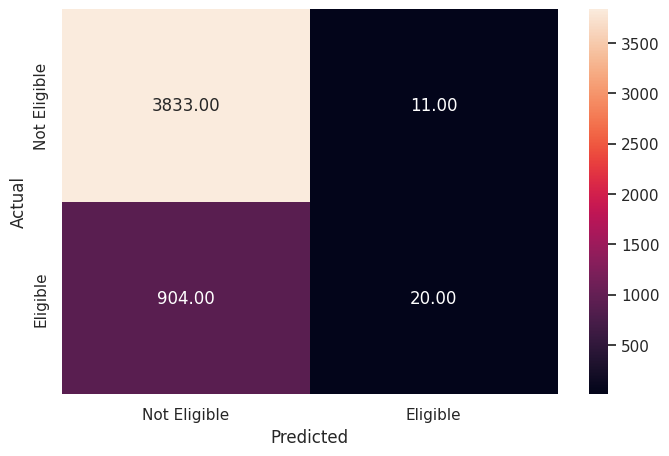

```python
#Predict for train set
y_train_pred = lr_model.predict(X_train)

metrics_score(y_train, y_train_pred)
```

#### Checking the performance on the test dataset

```
              precision    recall  f1-score   support

           0       0.78      1.00      0.88       927
           1       0.82      0.03      0.07       265

    accuracy                           0.78      1192
   macro avg       0.80      0.52      0.47      1192
weighted avg       0.79      0.78      0.70      1192
```

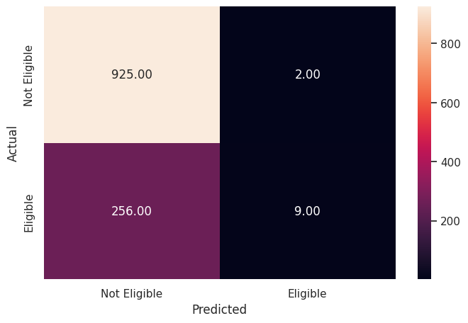

```python
# Predict for test set
y_test_pred = lr_model.predict(X_test)

metrics_score(y_test, y_test_pred)
```

```python
lr_test = model_performance_classification(lr_model, X_test, y_test)
lr_test
```

[output not shown]

#### Let's check the coefficients, and check which variables are important and how they affect the process of loan approval

```python
#@title
# Printing the coefficients of logistic regression
coefficients = model.coef_
intercept = model.intercept_

print("Coefficients of the model:", coefficients)
print("Intercept of the model:", intercept)
```

```
Coefficients of the model: [[-2.89268622e-05 -6.96099618e-06  2.36607776e-06 -6.67118593e-03
   4.57637350e-03  7.64504867e-03 -7.83035042e-03  5.77180628e-03
   5.44813077e-03  1.85126995e-02]]
Intercept of the model: [-0.00020256]
```

### **Think about it:**

- The above Logistic regression model was build on the threshold of 0.5, can we use different threshold?
- How to get an optimal threshold and which curve will help you achieve?
- How does, accuracy, precision and recall change on the threshold?

### **Build a Decision Tree Model**

### **Think about it:**

- In Logistic regression we treated the outliers and built the model, should we do the same for tree based models or not? If not, why?

For tree-based models like Decision Trees, Random Forests, the treatment of outliers is generally less critical. Tree-based models do not assume a specific distribution of the data. Also, the criteria for splitting in trees, such as information gain, are not significantly skewed by extreme values.

#### Data Preparation for the tree based model

```python
#@title
# Add binary flags
# List of columns that has missing values in it
#missing_col = [col for col in data.columns if data[col].isnull().any()]

#for colmn in missing_col:
#    add_binary_flag(data,colmn)
```

```python
#@title
#  Treat Missing values in numerical columns with median and mode in categorical variables
# Select numeric columns.
num_data = data.select_dtypes('number')

# Select string and object columns.
cat_data = data.select_dtypes('category').columns.tolist()#df.select_dtypes('object')

# Fill numeric columns with median.
# Remove _________ and complete the code
data[num_data.columns] = num_data.fillna(num_data.median())

# Fill object columns with model.
# Remove _________ and complete the code
for column in cat_data:
    mode = data[column].mode()[0]
    data[column] = data[column].fillna(mode)
```

#### Separating the target variable y and independent variable x

```python
# Creating the copy of the dataframe
df1 = df.copy()

# Drop the dependent variable from the dataframe and create the X(independent variable) matrix
X = df1.drop(columns=['BAD'])

# Create dummy variables for the categorical variables
X = pd.get_dummies(X, drop_first=True)

# Create y(dependent varibale)
y = df1['BAD']
```

#### Split the data

```python
# Split the data into training and test set
# Assuming we want to split the data with 80% for training and 20% for testing
X_train, X_test, y_train, y_test = train_test_split(X, y, test_size=0.2, random_state=42)
print(X_train.shape, X_test.shape)
```

```
(4768, 10) (1192, 10)
```

```python
#@title
#Defining Decision tree model with class weights class_weight={0: 0.2, 1: 0.8}
d_tree = DecisionTreeClassifier(class_weight={0: 0.2, 1: 0.8})
```

```python
#@title
#fitting Decision tree model
d_tree.fit(X_train, y_train)
```

```
DecisionTreeClassifier(class_weight={0: 0.2, 1: 0.8})
```

#### Checking the performance on the train dataset

```
              precision    recall  f1-score   support

           0       1.00      1.00      1.00      3844
           1       1.00      1.00      1.00       924

    accuracy                           1.00      4768
   macro avg       1.00      1.00      1.00      4768
weighted avg       1.00      1.00      1.00      4768
```

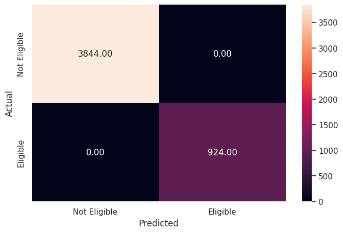

```python
#@title
# Checking performance on the training data

# Make predictions on the training data
y_train_pred = d_tree.predict(X_train)

metrics_score(y_train, y_train_pred)
```

#### Checking the performance on the test dataset

```
              precision    recall  f1-score   support

           0       0.90      0.93      0.91       927
           1       0.72      0.62      0.67       265

    accuracy                           0.86      1192
   macro avg       0.81      0.78      0.79      1192
weighted avg       0.86      0.86      0.86      1192
```

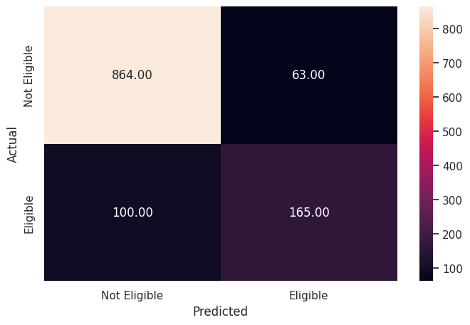

```python
#@title
# Checking performance on the testing data

# Make predictions on the testing data
y_test_pred = d_tree.predict(X_test)

metrics_score(y_test, y_test_pred)
```

```python
d_tree_test = model_performance_classification(d_tree, X_test, y_test)
d_tree_test
```

[output not shown]

### **Think about it:**

- Can we improve this model?
- How to get optimal parameters in order to get the best possible results?

### **Decision Tree - Hyperparameter Tuning**

- Hyperparameter tuning is tricky in the sense that **there is no direct way to calculate how a change in the hyperparameter value will reduce the loss of your model**, so we usually resort to experimentation. We'll use Grid search to perform hyperparameter tuning.
- **Grid search is a tuning technique that attempts to compute the optimum values of hyperparameters.**
- **It is an exhaustive search** that is performed on the specific parameter values of a model.
- The parameters of the estimator/model used to apply these methods are **optimized by cross-validated grid-search** over a parameter grid.

**Criterion {“gini”, “entropy”}**

The function to measure the quality of a split. Supported criteria are “gini” for the Gini impurity and “entropy” for the information gain.

**max_depth**

The maximum depth of the tree. If None, then nodes are expanded until all leaves are pure or until all leaves contain less than min_samples_split samples.

**min_samples_leaf**

The minimum number of samples is required to be at a leaf node. A split point at any depth will only be considered if it leaves at least min_samples_leaf training samples in each of the left and right branches. This may have the effect of smoothing the model, especially in regression.

You can learn about more Hyperpapameters on this link and try to tune them.

https://scikit-learn.org/stable/modules/generated/sklearn.tree.DecisionTreeClassifier.html

#### Using GridSearchCV for Hyperparameter tuning on the model

```python
# Choose the type of classifier
d_tree_tuned = DecisionTreeClassifier(random_state = 14, class_weight = {0: 0.2, 1: 0.8})

# Grid of parameters to choose from
parameters = {'max_depth': np.arange(2, 10),
              'criterion': ['gini', 'entropy'],
              'min_samples_leaf': [5, 10, 20, 25]
             }

# Type of scoring used to compare parameter combinations - recall score for class 1
scorer = metrics.make_scorer(recall_score, pos_label = 1)

# Run the grid search
grid_obj = GridSearchCV(d_tree_tuned, parameters, scoring = scorer, cv = 5)

grid_obj = grid_obj.fit(X_train, y_train)

# Set the classifier to the best combination of parameters
d_tree_tuned = grid_obj.best_estimator_

# Fit the best algorithm to the data
d_tree_tuned = d_tree_tuned.fit(X_train, y_train)
```

#### Checking the performance on the train dataset

```
              precision    recall  f1-score   support

           0       0.96      0.86      0.91      3844
           1       0.60      0.85      0.71       924

    accuracy                           0.86      4768
   macro avg       0.78      0.86      0.81      4768
weighted avg       0.89      0.86      0.87      4768
```

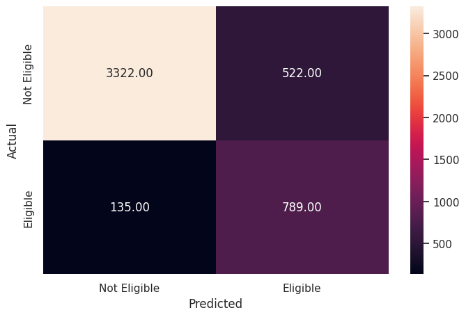

```python
# Check performance on the training data based on the tuned model
y_pred_train2 = d_tree_tuned.predict(X_train)

metrics_score(y_train, y_pred_train2)
```

#### Checking the performance on the test dataset

```
              precision    recall  f1-score   support

           0       0.95      0.87      0.90       927
           1       0.64      0.83      0.72       265

    accuracy                           0.86      1192
   macro avg       0.79      0.85      0.81      1192
weighted avg       0.88      0.86      0.86      1192
```

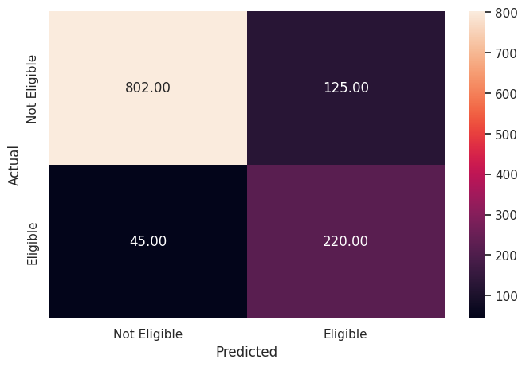

```python
# Check performance on the test data based on the tuned model
y_pred_test2 = d_tree_tuned.predict(X_test)

metrics_score(y_test, y_pred_test2)
```

```python
d_tree_tuned_test = model_performance_classification(d_tree_tuned, X_test, y_test)
d_tree_tuned_test
```

[output not shown]

#### Plotting the Decision Tree

[figure not shown]

```python
# Draw the decision tree for the tuned model

features = list(X.columns)

plt.figure(figsize = (90, 30))

out = tree.plot_tree(d_tree_tuned, feature_names = features, impurity = False, filled = True, fontsize = 10, class_names = None)

for o in out:

    arrow = o.arrow_patch

    if arrow is not None:

        arrow.set_edgecolor('gray')

        arrow.set_linewidth(1)

plt.show()
```

INSIGHTS:

Following combination seems to have the lowest default rate:

- DELINQ < 0.5
- CLAGE < 178.2
- DEROG < 0.5
- LOAN < 18,100

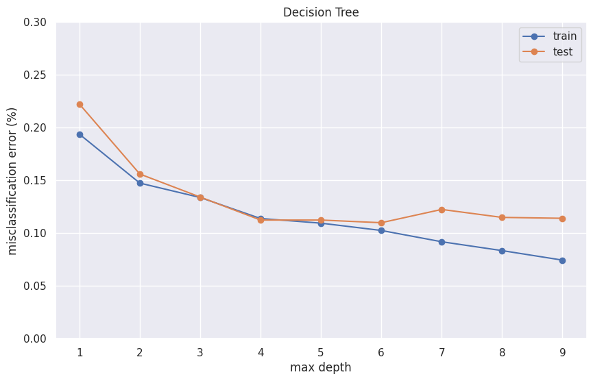

```python
# Visualize and compare error on the training and test data for different values of max_depth in the decision tree classifier.
train_scores = []
test_scores = []

for depth in range(1, 10):

    d_tree3 = tree.DecisionTreeClassifier(criterion = 'entropy', max_depth = depth)

    d_tree3 = d_tree3.fit(X_train, y_train)

    train_scores.append(1 - d_tree3.score(X_train, y_train))

    test_scores.append(1 - d_tree3.score(X_test, y_test))

plt.plot(range(1, 10), train_scores, '-o', label = "train")

plt.plot(range(1, 10), test_scores, '-o', label = "test")

plt.legend(loc = 'best')

plt.xlabel('max depth')

plt.ylabel('misclassification error (%)')

# Setting the range of the Y-axis
plt.ylim(0, 0.3)

plt.title("Decision Tree")

fig = plt.gcf()

fig.set_size_inches(10, 6)

plt.show()
```

### **Building a Random Forest Classifier**

**Random Forest is a bagging algorithm where the base models are Decision Trees.** Samples are taken from the training data and on each sample a decision tree makes a prediction.

**The results from all the decision trees are combined together and the final prediction is made using voting or averaging.**

```python
# Fitting the random forest tree classifier on the training data
rf_estimator =  ensemble.RandomForestClassifier()

rf_estimator = rf_estimator.fit(X_train, y_train)
```

#### Checking the performance on the train dataset

```
              precision    recall  f1-score   support

           0       1.00      1.00      1.00      3844
           1       1.00      1.00      1.00       924

    accuracy                           1.00      4768
   macro avg       1.00      1.00      1.00      4768
weighted avg       1.00      1.00      1.00      4768
```

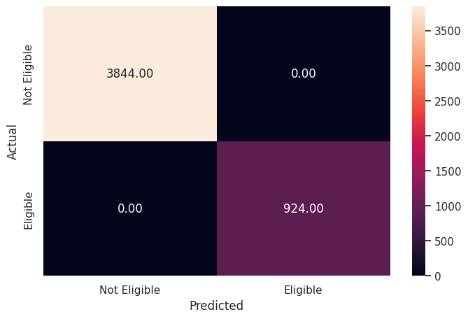

```python
# Checking performance on the training data
y_pred_train3 = rf_estimator.predict(X_train)

metrics_score(y_train, y_pred_train3)
```

#### Checking the performance on the test dataset

```
              precision    recall  f1-score   support

           0       0.92      0.97      0.94       927
           1       0.87      0.70      0.78       265

    accuracy                           0.91      1192
   macro avg       0.90      0.84      0.86      1192
weighted avg       0.91      0.91      0.91      1192
```

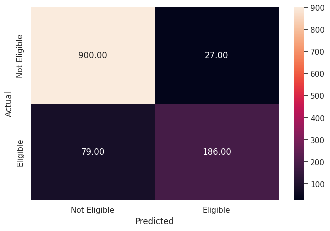

```python
#@title
# Checking performance on the test data
y_pred_test3 = rf_estimator.predict(X_test)

metrics_score(y_test, y_pred_test3)
```

```python
rf_estimator_test = model_performance_classification(rf_estimator, X_test, y_test)
rf_estimator_test
```

[output not shown]

### **Build a Random Forest model with Class Weights**

```python
# Choose the type of classifier
rf_estimator_tuned = RandomForestClassifier(criterion = "entropy", random_state = 7)

# Grid of parameters to choose from
parameters = {"n_estimators": [110, 120],
    "max_depth": [6, 7],
    "min_samples_leaf": [20, 25],
    "max_features": [0.8, 0.9],
    "max_samples": [0.9, 1],
    "class_weight": ["balanced",{0: 0.2, 1: 0.8}]
}

# Type of scoring used to compare parameter combinations - recall score for class 1
scorer = metrics.make_scorer(recall_score, pos_label = 1)

# Run the grid search on the training data using scorer=scorer and cv=5
grid_obj = GridSearchCV(rf_estimator_tuned, parameters, scoring = scorer, cv = 5)

grid_obj = grid_obj.fit(X_train, y_pred_train3)

# Save the best estimator to variable rf_estimator_tuned
rf_estimator_tuned = grid_obj.best_estimator_

# Fit the best estimator to the training data
rf_estimator_tuned = rf_estimator_tuned.fit(X_train, y_pred_train3)
```

#### Checking the performance on the train dataset

```
              precision    recall  f1-score   support

           0       0.95      0.89      0.92      3844
           1       0.64      0.79      0.71       924

    accuracy                           0.87      4768
   macro avg       0.79      0.84      0.81      4768
weighted avg       0.89      0.87      0.88      4768
```

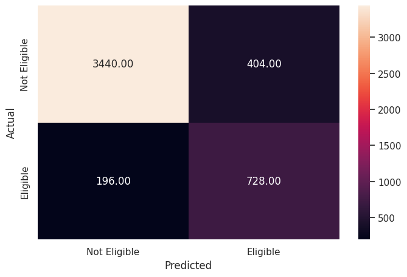

```python
# Checking performance on the train data
y_pred_train4 = rf_estimator_tuned.predict(X_train)

metrics_score(y_train, y_pred_train4)
```

#### Checking the performance on the test dataset

```
              precision    recall  f1-score   support

           0       0.93      0.89      0.91       927
           1       0.68      0.78      0.73       265

    accuracy                           0.87      1192
   macro avg       0.81      0.84      0.82      1192
weighted avg       0.88      0.87      0.87      1192
```

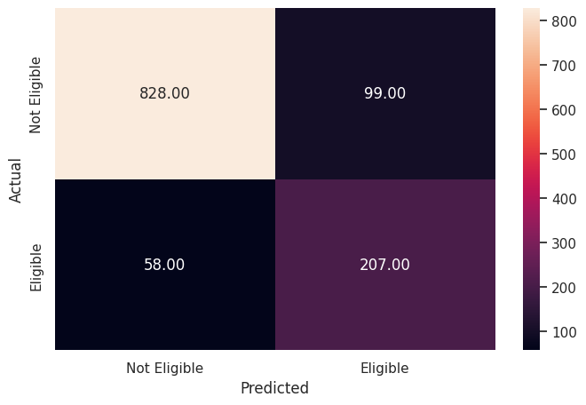

```python
#@title
# Checking performance on the test data
y_pred_test4 = rf_estimator_tuned.predict(X_test)

metrics_score(y_test, y_pred_test4)
```

```python
rf_estimator_tuned_test = model_performance_classification(rf_estimator_tuned, X_test, y_test)
rf_estimator_tuned_test
```

[output not shown]

### **Think about it:**

- Can we try different weights?
- If yes, should we increase or decrease class weights for different classes?

### **Tuning the Random Forest**

- Hyperparameter tuning is tricky in the sense that **there is no direct way to calculate how a change in the hyperparameter value will reduce the loss of your model**, so we usually resort to experimentation. We'll use Grid search to perform hyperparameter tuning.
- **Grid search is a tuning technique that attempts to compute the optimum values of hyperparameters.**
- **It is an exhaustive search** that is performed on the specific parameter values of a model.
- The parameters of the estimator/model used to apply these methods are **optimized by cross-validated grid-search** over a parameter grid.

**n_estimators**: The number of trees in the forest.

**min_samples_split**: The minimum number of samples required to split an internal node:

**min_samples_leaf**: The minimum number of samples required to be at a leaf node.

**max_features{“auto”, “sqrt”, “log2”, 'None'}**: The number of features to consider when looking for the best split.

- If “auto”, then max_features=sqrt(n_features).
- If “sqrt”, then max_features=sqrt(n_features) (same as “auto”).
- If “log2”, then max_features=log2(n_features).
- If None, then max_features=n_features.

You can learn more about Random Forest Hyperparameters from the link given below and try to tune them

https://scikit-learn.org/stable/modules/generated/sklearn.ensemble.RandomForestClassifier.html

#### **Warning:** This may take a long time depending on the parameters you tune.

```python
#@title
# Choose the type of classifier
model = RandomForestClassifier()

# Grid of parameters to choose from
param_grid = {
    'n_estimators': [100, 200, 300],
    'max_depth': [None, 10, 20, 30],
    'min_samples_split': [2, 5, 10],
    'min_samples_leaf': [1, 2, 4],
    'bootstrap': [True, False]
}

# Type of scoring used to compare parameter combinations
scoring = 'accuracy'

# Run the grid search
grid_search = GridSearchCV(estimator=model, param_grid=param_grid, scoring=scoring, cv=5, n_jobs=-1, verbose=2)

# Fit the GridSearch on train dataset
grid_search.fit(X_train, y_train)

# Set the model to the best combination of parameters
best_model = grid_search.best_estimator_

# Fit the best algorithm to the data
best_model.fit(X_train, y_train)
```

```
Fitting 5 folds for each of 216 candidates, totalling 1080 fits
```

```
RandomForestClassifier(bootstrap=False, max_depth=30, n_estimators=200)
```

```python
#@title
# Checking performance on the train data
y_pred_train4 = best_model.predict(X_train)
```

```python
#@title
# Checking performace on test dataset
y_pred_test4 = best_model.predict(X_test)
```

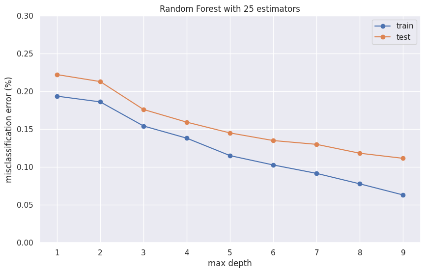

```python
# Visualize and compare error on the training and test data for different values of max_depth in the random forest classifier.
train_scores = []
test_scores = []

for depth in range(1, 10):

    rf1 = RandomForestClassifier(random_state = 0, criterion = 'entropy', max_depth = depth, n_estimators = 25)

    rf1 = rf1.fit(X_train, y_train)

    train_scores.append(1 - rf1.score(X_train, y_train))

    test_scores.append(1 - rf1.score(X_test, y_test))

plt.plot(range(1, 10), train_scores, '-o', label = "train")

plt.plot(range(1, 10), test_scores, '-o', label = "test")

plt.legend(loc = 'upper right')

plt.xlabel('max depth')

plt.ylim(0, 0.3)

plt.ylabel('misclassification error (%)')

plt.title(f"Random Forest with 25 estimators")

fig = plt.gcf()

fig.set_size_inches(10, 6)

plt.show()
```

**Insights: Random Forest misclassification error rate looks worse than the one for Decision Tree.**

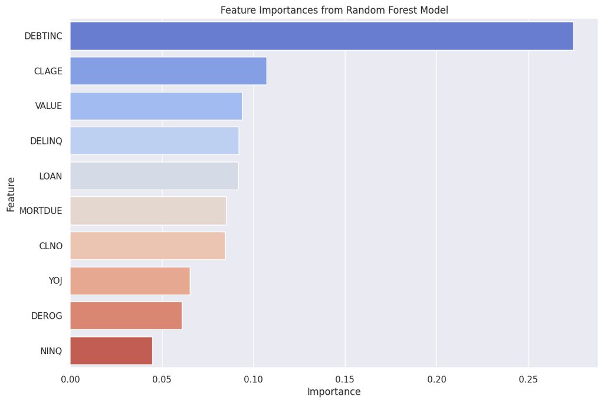

```python
# Creating the copy of the dataframe
df1 = df.copy()

# Define the target variable 'BAD' and the features
X = df1.drop(columns=['BAD'])  # Features (all columns except 'BAD')
y = df1['BAD']  # Target variable

# Identify categorical columns
categorical_cols = X.select_dtypes(include=['object']).columns
numeric_cols = X.select_dtypes(exclude=['object']).columns

# Create and fit the OneHotEncoder separately to get feature names
onehot_encoder = OneHotEncoder(handle_unknown='ignore', sparse=False)
onehot_encoder.fit(X[categorical_cols])

# Get the transformed feature names after one-hot encoding
onehot_feature_names = onehot_encoder.get_feature_names_out(categorical_cols)

# Combine the one-hot encoded feature names with the numeric feature names
all_feature_names = list(onehot_feature_names) + list(numeric_cols)

# Create a preprocessing pipeline for categorical data
preprocessor = ColumnTransformer(
    transformers=[
        ('cat', onehot_encoder, categorical_cols)
    ],
    remainder='passthrough'  # Keep the remaining numeric columns as they are
)

# Create a Random Forest pipeline
model_pipeline = Pipeline(steps=[
    ('preprocessor', preprocessor),
    ('classifier', RandomForestClassifier(random_state=42))
])

# Split the data into training and testing sets
X_train, X_test, y_train, y_test = train_test_split(X, y, test_size=0.2, random_state=42)

# Train the model using the pipeline
model_pipeline.fit(X_train, y_train)

# Extract feature importances from the trained Random Forest model
importances = model_pipeline.named_steps['classifier'].feature_importances_

# Create a DataFrame to hold feature names and their corresponding importances
feature_importance_df = pd.DataFrame({
    'Feature': all_feature_names,
    'Importance': importances
})

# Sort the DataFrame by importance
feature_importance_df = feature_importance_df.sort_values(by='Importance', ascending=False)

# Visualize the feature importances
plt.figure(figsize=(12, 8))
sns.barplot(x=feature_importance_df['Importance'], y=feature_importance_df['Feature'], palette='coolwarm')
plt.title('Feature Importances from Random Forest Model')
plt.xlabel('Importance')
plt.ylabel('Feature')
plt.show()
```

### **Think about it:**

- We have only built 3 models so far, Logistic Regression, Decision Tree and Random Forest
- We can build other Machine Learning classification models like kNN, LDA, QDA or even Support Vector Machines (SVM).
- Can we also perform feature engineering and create model features and build a more robust and accurate model for this problem statement?

### **Comparing Model Performances**

```python
# Compare the models
models = {
    'Logistic Regression': lr_model,
    'Decision Tree': d_tree,
    'Decision Tree Tuned': d_tree_tuned,
    'Random Forest': rf_estimator,
    'Random Forest Tuned': rf_estimator_tuned
}

performance_df = model_performance_classification(models, X_test, y_test)

# Display the performance metrics
#print(performance_df)

from tabulate import tabulate
print(tabulate(performance_df, headers='keys', tablefmt='fancy_grid', showindex=False))
```

```
╒═════════════════════╤═══════════╤═════════════╤════════════╤════════════╕
│ Model               │    Recall │   Precision │   F1 Score │   Accuracy │
╞═════════════════════╪═══════════╪═════════════╪════════════╪════════════╡
│ Logistic Regression │ 0.0339623 │    0.818182 │  0.0652174 │   0.783557 │
├─────────────────────┼───────────┼─────────────┼────────────┼────────────┤
│ Decision Tree       │ 0.622642  │    0.723684 │  0.669371  │   0.863255 │
├─────────────────────┼───────────┼─────────────┼────────────┼────────────┤
│ Decision Tree Tuned │ 0.830189  │    0.637681 │  0.721311  │   0.857383 │
├─────────────────────┼───────────┼─────────────┼────────────┼────────────┤
│ Random Forest       │ 0.701887  │    0.873239 │  0.778243  │   0.911074 │
├─────────────────────┼───────────┼─────────────┼────────────┼────────────┤
│ Random Forest Tuned │ 0.781132  │    0.676471 │  0.725044  │   0.868289 │
╘═════════════════════╧═══════════╧═════════════╧════════════╧════════════╛
```

**1. Comparison of various techniques and their relative performance based on chosen Metric (Measure of success):**

- How do different techniques perform? Which one is performing relatively better? Is there scope to improve the performance further?

**2. Refined insights:**

- What are the most meaningful insights relevant to the problem?

**3. Proposal for the final solution design:**

- What model do you propose to be adopted? Why is this the best solution to adopt?

**Gradient Boosting Machines** (XGBoost, LightGBM) can also be used due to their balance between performance and flexibility, especially in dealing with complex, imbalanced datasets.